# Gaussian Processes Regression

Andrew Esch, Evan Lee, and Collin Stratton

3-13-2022

## Introduction: Gene Expression and Differential Expressions

Gene Expression is the biological process found in cells in which genetic information (coded in the set of bases A, G, T, and C) is decoded and utilized to form a set of genetic products. It is a tightly regulated process which allows cells to respond to its changing environments, and it acts as an on/off switch or a protein volume controller to increase or decrease the amount of proteins being product. There are two major steps involved in gene expression, those being transcription and translation. Transcription is the copying of a DNA gene to produce a RNA transcript called mRNA. Translation takes the information from the mRNA, reads the amino acids on the strand using tRNA, then builds a polypeptide chain from the correct codes. The types of products that the process of gene expression can produce includes amino acids and proteins. This process is essential foundation for the formation of all biological life, and the differences in gene expression between cells is an important area of biology for further study.

Differential expression is the observation of a statistically significant difference or change in read counts or expression levels. To find a differential expression between genes, it is important to use statistical models to find if there is statistically significant difference for these metrics.

## Control and Treatment Categorizations

A control is a group categorization that does not have any affected conditions. In other words, this group acts as the baseline for all other measurements in a model. The standard for most models is to feature one control. Alternatively, a treatment is a type of group categorization that has been affected by some type of condition. They are also known as experimental group categorizations. A model may feature several treatments.

## Setup

```r
#RUN ONCE THEN COMMENT OUT
# if (!requireNamespace("BiocManager"))
   # install.packages("BiocManager")
# BiocManager::install(c("limma", "edgeR", "Glimma", "org.Mm.eg.db", "gplots", "RColorBrewer", "NMF", "BiasedUrn"))

library(edgeR)
library(limma)
library(Glimma)
library(org.Mm.eg.db)
library(gplots)
library(RColorBrewer)
library(NMF)
library(MASS)
library(plyr)
library(reshape2)
library(ggplot2)
library(GauPro)
library(kernlab)
set.seed(1234)
```

```r
#Evan Import -> C:/GCU Academics/Junior Year/Second Semester/CST-425/CLC Shared GitHub Repository/Cloned Repository/GaussianProcessesRegression/

#Andrew Import -> C:/Users/andre/Documents/GitHub/CST-425/GaussianProcessesRegression/

#Collin Import -> /Users/collinstratton/Google Drive/School/GCU/Fall 2021 - Spring 2022/CST-425/CST-425/GaussianProcessesRegression/

# Read the data into R
seqdata <- read.delim("C:/GCU Academics/Junior Year/Second Semester/CST-425/CLC Shared GitHub Repository/Cloned Repository/GaussianProcessesRegression/GSE60450_LactationGenewiseCounts.txt", stringsAsFactors = FALSE)
# Read the sample information into R
sampleinfo <- read.delim("C:/GCU Academics/Junior Year/Second Semester/CST-425/CLC Shared GitHub Repository/Cloned Repository/GaussianProcessesRegression/SampleInfo.txt", stringsAsFactors = TRUE)

head(seqdata)
```

|  | EntrezGeneID | Length | MCL1.DG_BC2CTUACXX_ACTTGA_L002_R1 | MCL1.DH_BC2CTUACXX_CAGATC_L002_R1 | MCL1.DI_BC2CTUACXX_ACAGTG_L002_R1 | MCL1.DJ_BC2CTUACXX_CGATGT_L002_R1 | MCL1.DK_BC2CTUACXX_TTAGGC_L002_R1 | MCL1.DL_BC2CTUACXX_ATCACG_L002_R1 | MCL1.LA_BC2CTUACXX_GATCAG_L001_R1 | MCL1.LB_BC2CTUACXX_TGACCA_L001_R1 | MCL1.LC_BC2CTUACXX_GCCAAT_L001_R1 | MCL1.LD_BC2CTUACXX_GGCTAC_L001_R1 | MCL1.LE_BC2CTUACXX_TAGCTT_L001_R1 | MCL1.LF_BC2CTUACXX_CTTGTA_L001_R1 |
| --- | --- | --- | --- | --- | --- | --- | --- | --- | --- | --- | --- | --- | --- | --- |
| 1 | 497097 | 3634 | 438 | 300 | 65 | 237 | 354 | 287 | 0 | 0 | 0 | 0 | 0 | 0 |
| 2 | 100503874 | 3259 | 1 | 0 | 1 | 1 | 0 | 4 | 0 | 0 | 0 | 0 | 0 | 0 |
| 3 | 100038431 | 1634 | 0 | 0 | 0 | 0 | 0 | 0 | 0 | 0 | 0 | 0 | 0 | 0 |
| 4 | 19888 | 9747 | 1 | 1 | 0 | 0 | 0 | 0 | 10 | 3 | 10 | 2 | 0 | 0 |
| 5 | 20671 | 3130 | 106 | 182 | 82 | 105 | 43 | 82 | 16 | 25 | 18 | 8 | 3 | 10 |
| 6 | 27395 | 4203 | 309 | 234 | 337 | 300 | 290 | 270 | 560 | 464 | 489 | 328 | 307 | 342 |

```r
dim(seqdata)
```

```
[1] 27179    14
```

```r
sampleinfo
```

| FileName | SampleName | CellType | Status |
| --- | --- | --- | --- |
| MCL1.DG_BC2CTUACXX_ACTTGA_L002_R1 | MCL1.DG | luminal | virgin |
| MCL1.DH_BC2CTUACXX_CAGATC_L002_R1 | MCL1.DH | basal | virgin |
| MCL1.DI_BC2CTUACXX_ACAGTG_L002_R1 | MCL1.DI | basal | pregnant |
| MCL1.DJ_BC2CTUACXX_CGATGT_L002_R1 | MCL1.DJ | basal | pregnant |
| MCL1.DK_BC2CTUACXX_TTAGGC_L002_R1 | MCL1.DK | basal | lactate |
| MCL1.DL_BC2CTUACXX_ATCACG_L002_R1 | MCL1.DL | basal | lactate |
| MCL1.LA_BC2CTUACXX_GATCAG_L001_R1 | MCL1.LA | basal | virgin |
| MCL1.LB_BC2CTUACXX_TGACCA_L001_R1 | MCL1.LB | luminal | virgin |
| MCL1.LC_BC2CTUACXX_GCCAAT_L001_R1 | MCL1.LC | luminal | pregnant |
| MCL1.LD_BC2CTUACXX_GGCTAC_L001_R1 | MCL1.LD | luminal | pregnant |

[output cut: 2 more lines]

```r
# Remove first two columns from seqdata
countdata <- seqdata[,-(1:2)]

# Look at the output
head(countdata)
```

|  | MCL1.DG_BC2CTUACXX_ACTTGA_L002_R1 | MCL1.DH_BC2CTUACXX_CAGATC_L002_R1 | MCL1.DI_BC2CTUACXX_ACAGTG_L002_R1 | MCL1.DJ_BC2CTUACXX_CGATGT_L002_R1 | MCL1.DK_BC2CTUACXX_TTAGGC_L002_R1 | MCL1.DL_BC2CTUACXX_ATCACG_L002_R1 | MCL1.LA_BC2CTUACXX_GATCAG_L001_R1 | MCL1.LB_BC2CTUACXX_TGACCA_L001_R1 | MCL1.LC_BC2CTUACXX_GCCAAT_L001_R1 | MCL1.LD_BC2CTUACXX_GGCTAC_L001_R1 | MCL1.LE_BC2CTUACXX_TAGCTT_L001_R1 | MCL1.LF_BC2CTUACXX_CTTGTA_L001_R1 |
| --- | --- | --- | --- | --- | --- | --- | --- | --- | --- | --- | --- | --- |
| 1 | 438 | 300 | 65 | 237 | 354 | 287 | 0 | 0 | 0 | 0 | 0 | 0 |
| 2 | 1 | 0 | 1 | 1 | 0 | 4 | 0 | 0 | 0 | 0 | 0 | 0 |
| 3 | 0 | 0 | 0 | 0 | 0 | 0 | 0 | 0 | 0 | 0 | 0 | 0 |
| 4 | 1 | 1 | 0 | 0 | 0 | 0 | 10 | 3 | 10 | 2 | 0 | 0 |
| 5 | 106 | 182 | 82 | 105 | 43 | 82 | 16 | 25 | 18 | 8 | 3 | 10 |
| 6 | 309 | 234 | 337 | 300 | 290 | 270 | 560 | 464 | 489 | 328 | 307 | 342 |

```r
colnames(countdata)
```

```
 [1] "MCL1.DG_BC2CTUACXX_ACTTGA_L002_R1" "MCL1.DH_BC2CTUACXX_CAGATC_L002_R1"
 [3] "MCL1.DI_BC2CTUACXX_ACAGTG_L002_R1" "MCL1.DJ_BC2CTUACXX_CGATGT_L002_R1"
 [5] "MCL1.DK_BC2CTUACXX_TTAGGC_L002_R1" "MCL1.DL_BC2CTUACXX_ATCACG_L002_R1"
 [7] "MCL1.LA_BC2CTUACXX_GATCAG_L001_R1" "MCL1.LB_BC2CTUACXX_TGACCA_L001_R1"
 [9] "MCL1.LC_BC2CTUACXX_GCCAAT_L001_R1" "MCL1.LD_BC2CTUACXX_GGCTAC_L001_R1"
[11] "MCL1.LE_BC2CTUACXX_TAGCTT_L001_R1" "MCL1.LF_BC2CTUACXX_CTTGTA_L001_R1"
```

[output not shown]

```r
# using substr, you extract the characters starting at position 1 and stopping at position 7 of the colnames
colnames(countdata) <- substr(colnames(countdata),start=1,stop=7)
head(countdata)
```

|  | MCL1.DG | MCL1.DH | MCL1.DI | MCL1.DJ | MCL1.DK | MCL1.DL | MCL1.LA | MCL1.LB | MCL1.LC | MCL1.LD | MCL1.LE | MCL1.LF |
| --- | --- | --- | --- | --- | --- | --- | --- | --- | --- | --- | --- | --- |
| 1 | 438 | 300 | 65 | 237 | 354 | 287 | 0 | 0 | 0 | 0 | 0 | 0 |
| 2 | 1 | 0 | 1 | 1 | 0 | 4 | 0 | 0 | 0 | 0 | 0 | 0 |
| 3 | 0 | 0 | 0 | 0 | 0 | 0 | 0 | 0 | 0 | 0 | 0 | 0 |
| 4 | 1 | 1 | 0 | 0 | 0 | 0 | 10 | 3 | 10 | 2 | 0 | 0 |
| 5 | 106 | 182 | 82 | 105 | 43 | 82 | 16 | 25 | 18 | 8 | 3 | 10 |
| 6 | 309 | 234 | 337 | 300 | 290 | 270 | 560 | 464 | 489 | 328 | 307 | 342 |

### Create a DGEList Object

The DGEList is an object used by edgeR to store count data. It has a number of slots for storing various parameters about the data.

```r
dglist <- DGEList(countdata)

dglist
```

```
An object of class "DGEList"
$counts
  MCL1.DG MCL1.DH MCL1.DI MCL1.DJ MCL1.DK MCL1.DL MCL1.LA MCL1.LB MCL1.LC
1     438     300      65     237     354     287       0       0       0
2       1       0       1       1       0       4       0       0       0
3       0       0       0       0       0       0       0       0       0
4       1       1       0       0       0       0      10       3      10
5     106     182      82     105      43      82      16      25      18
  MCL1.LD MCL1.LE MCL1.LF
1       0       0       0
2       0       0       0
3       0       0       0
4       2       0       0
5       8       3      10
27174 more rows ...

$samples
        group lib.size norm.factors
MCL1.DG     1 23227641            1
MCL1.DH     1 21777891            1
MCL1.DI     1 24100765            1
MCL1.DJ     1 22665371            1
MCL1.DK     1 21529331            1
7 more rows ...
```

```r
names(dglist)
```

```
[1] "counts"  "samples"
```

```
counts

samples
```

```r
group <- paste(sampleinfo$CellType,sampleinfo$Status,sep=".")
group <- factor(group)
group
```

```
 [1] luminal.virgin   basal.virgin     basal.pregnant   basal.pregnant
 [5] basal.lactate    basal.lactate    basal.virgin     luminal.virgin
 [9] luminal.pregnant luminal.pregnant luminal.lactate  luminal.lactate
6 Levels: basal.lactate basal.pregnant basal.virgin ... luminal.virgin
```

```r
dglist$samples$group <- group
dglist$samples
```

|  | group | lib.size | norm.factors |
| --- | --- | --- | --- |
| MCL1.DG | luminal.virgin | 23227641 | 1 |
| MCL1.DH | basal.virgin | 21777891 | 1 |
| MCL1.DI | basal.pregnant | 24100765 | 1 |
| MCL1.DJ | basal.pregnant | 22665371 | 1 |
| MCL1.DK | basal.lactate | 21529331 | 1 |
| MCL1.DL | basal.lactate | 20015386 | 1 |
| MCL1.LA | basal.virgin | 20392113 | 1 |
| MCL1.LB | luminal.virgin | 21708152 | 1 |
| MCL1.LC | luminal.pregnant | 22241607 | 1 |
| MCL1.LD | luminal.pregnant | 21988240 | 1 |

[output cut: 2 more lines]

```r
columns(org.Mm.eg.db)
```

```
 [1] "ACCNUM"       "ALIAS"        "ENSEMBL"      "ENSEMBLPROT"  "ENSEMBLTRANS"
 [6] "ENTREZID"     "ENZYME"       "EVIDENCE"     "EVIDENCEALL"  "GENENAME"
[11] "GENETYPE"     "GO"           "GOALL"        "IPI"          "MGI"
[16] "ONTOLOGY"     "ONTOLOGYALL"  "PATH"         "PFAM"         "PMID"
[21] "PROSITE"      "REFSEQ"       "SYMBOL"       "UNIPROT"
```

[output not shown]

```r
#ann <- select(org.Mm.eg.db,keys=rownames(dglist$counts),columns=c("ENTREZID","SYMBOL","GENENAME"))
#table(ann$ENTREZID==rownames(dglist$counts))
#dglist$genes <- ann
```

## Filtering Out Genes

Listed genes with very low counts provide little evidence for differential expression, and they interfere with some statistical approximations. Furthermore, they also add to the multiple testing burden when estimating false discovery rates, reducing power to detect differentially expressed genes. Thus, this next block of code filters out genes with very low counts.

```r
# Obtain CPMs
myCPM <- cpm(countdata)

# Have a look at the output
head(myCPM)
```

```
         MCL1.DG     MCL1.DH     MCL1.DI     MCL1.DJ   MCL1.DK    MCL1.DL
[1,] 18.85684388 13.77543859  2.69700983 10.45648006 16.442685 14.3389690
[2,]  0.04305215  0.00000000  0.04149246  0.04412017  0.000000  0.1998463
[3,]  0.00000000  0.00000000  0.00000000  0.00000000  0.000000  0.0000000
[4,]  0.04305215  0.04591813  0.00000000  0.00000000  0.000000  0.0000000
[5,]  4.56352843  8.35709941  3.40238163  4.63261775  1.997275  4.0968483
[6,] 13.30311589 10.74484210 13.98295863 13.23605071 13.469996 13.4896224
        MCL1.LA    MCL1.LB    MCL1.LC     MCL1.LD    MCL1.LE    MCL1.LF
[1,]  0.0000000  0.0000000  0.0000000  0.00000000  0.0000000  0.0000000
[2,]  0.0000000  0.0000000  0.0000000  0.00000000  0.0000000  0.0000000
[3,]  0.0000000  0.0000000  0.0000000  0.00000000  0.0000000  0.0000000
[4,]  0.4903857  0.1381969  0.4496078  0.09095771  0.0000000  0.0000000
[5,]  0.7846171  1.1516411  0.8092940  0.36383085  0.1213404  0.4055595
[6,] 27.4615975 21.3744588 21.9858214 14.91706476 12.4171715 13.8701357
```

```r
# Which values in myCPM are greater than 0.5?
thresh <- myCPM > 0.5

# This produces a logical matrix with TRUEs and FALSEs
head(thresh)
```

```
     MCL1.DG MCL1.DH MCL1.DI MCL1.DJ MCL1.DK MCL1.DL MCL1.LA MCL1.LB MCL1.LC
[1,]    TRUE    TRUE    TRUE    TRUE    TRUE    TRUE   FALSE   FALSE   FALSE
[2,]   FALSE   FALSE   FALSE   FALSE   FALSE   FALSE   FALSE   FALSE   FALSE
[3,]   FALSE   FALSE   FALSE   FALSE   FALSE   FALSE   FALSE   FALSE   FALSE
[4,]   FALSE   FALSE   FALSE   FALSE   FALSE   FALSE   FALSE   FALSE   FALSE
[5,]    TRUE    TRUE    TRUE    TRUE    TRUE    TRUE    TRUE    TRUE    TRUE
[6,]    TRUE    TRUE    TRUE    TRUE    TRUE    TRUE    TRUE    TRUE    TRUE
     MCL1.LD MCL1.LE MCL1.LF
[1,]   FALSE   FALSE   FALSE
[2,]   FALSE   FALSE   FALSE
[3,]   FALSE   FALSE   FALSE
[4,]   FALSE   FALSE   FALSE
[5,]   FALSE   FALSE   FALSE
[6,]    TRUE    TRUE    TRUE
```

```r
# Summary of how many TRUEs there are in each row
# There are 11433 genes that have TRUEs in all 12 samples.
table(rowSums(thresh))
```

```
    0     1     2     3     4     5     6     7     8     9    10    11    12
10857   518   544   307   346   307   652   323   547   343   579   423 11433
```

```r
# we would like to keep genes that have at least 2 TRUES in each row of thresh
keep <- rowSums(thresh) >= 2
summary(keep)
```

```
   Mode   FALSE    TRUE
logical   11375   15804
```

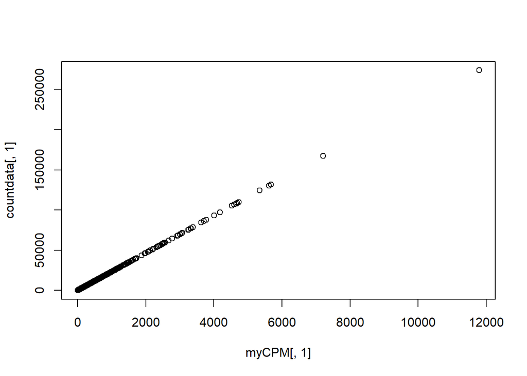

```r
# Let's have a look and see whether our threshold of 0.5 does indeed correspond to a count of about 10-15
# We will look at the first sample
plot(myCPM[,1],countdata[,1])
```

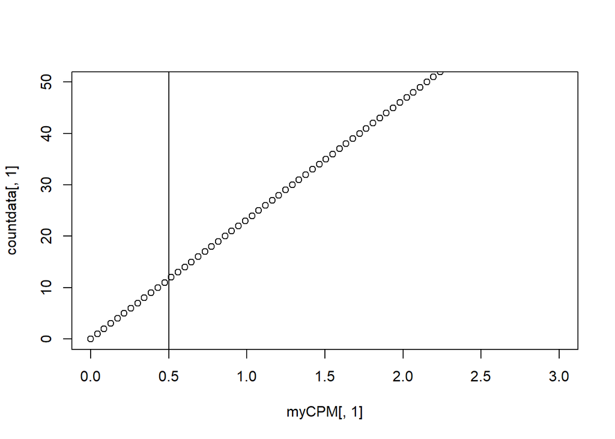

```r
# Let us limit the x and y-axis so we can actually look to see what is happening at the smaller counts
plot(myCPM[,1],countdata[,1],ylim=c(0,50),xlim=c(0,3))
# Add a vertical line at 0.5 CPM
abline(v=0.5)
```

```r
dglist <- dglist[keep, keep.lib.sizes=FALSE]
```

## Quality Control

With all the low-count genes filtering out, quality control of the data can now proceed. These next sections will look at graphs to be able to determine whether the data is appropriate for further analysis.

```r
dglist$samples$lib.size
```

```
 [1] 23218026 21768136 24091588 22656713 21522033 20008326 20384562 21698793
 [9] 22235847 21982745 24719697 24652963
```

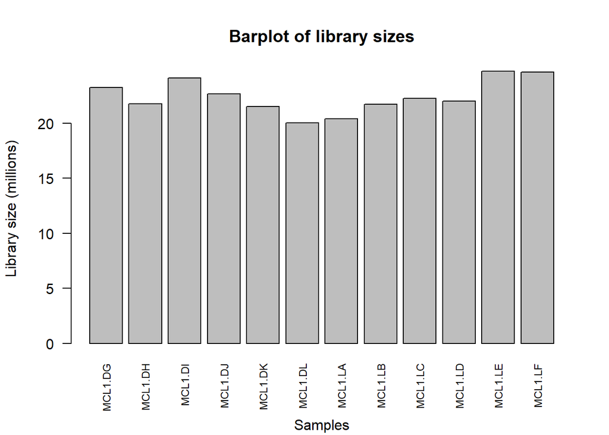

```r
# The names argument tells the barplot to use the sample names on the x-axis
# The las argument rotates the axis names

barplot(dglist$samples$lib.size/1e06, names=colnames(dglist), las=2, ann=FALSE, cex.names=0.75)
mtext(side = 1, text = "Samples", line = 4)
mtext(side = 2, text = "Library size (millions)", line = 3)
title("Barplot of library sizes")
```

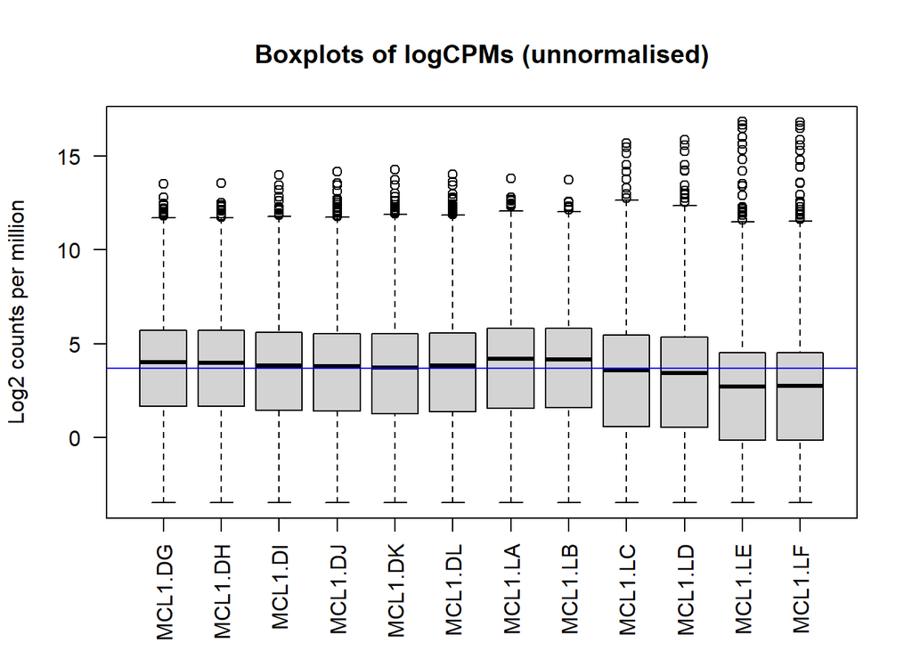

```r
# Get log2 counts per million
logcounts <- cpm(dglist,log=TRUE)
# Check distributions of samples using boxplots
boxplot(logcounts, xlab="", ylab="Log2 counts per million",las=2)
# Let's add a blue horizontal line that corresponds to the median logCPM
abline(h=median(logcounts),col="blue")
title("Boxplots of logCPMs (unnormalised)")
```

```r
logcounts <- cpm(dglist,log=TRUE)
# Apply normalisation to DGEList object
dglist <- calcNormFactors(dglist)
dglist$samples
```

|  | group | lib.size | norm.factors |
| --- | --- | --- | --- |
| MCL1.DG | luminal.virgin | 23218026 | 1.2368993 |
| MCL1.DH | basal.virgin | 21768136 | 1.2139485 |
| MCL1.DI | basal.pregnant | 24091588 | 1.1255640 |
| MCL1.DJ | basal.pregnant | 22656713 | 1.0698261 |
| MCL1.DK | basal.lactate | 21522033 | 1.0359212 |
| MCL1.DL | basal.lactate | 20008326 | 1.0872153 |
| MCL1.LA | basal.virgin | 20384562 | 1.3684449 |
| MCL1.LB | luminal.virgin | 21698793 | 1.3653200 |
| MCL1.LC | luminal.pregnant | 22235847 | 1.0047431 |
| MCL1.LD | luminal.pregnant | 21982745 | 0.9232822 |

[output cut: 2 more lines]

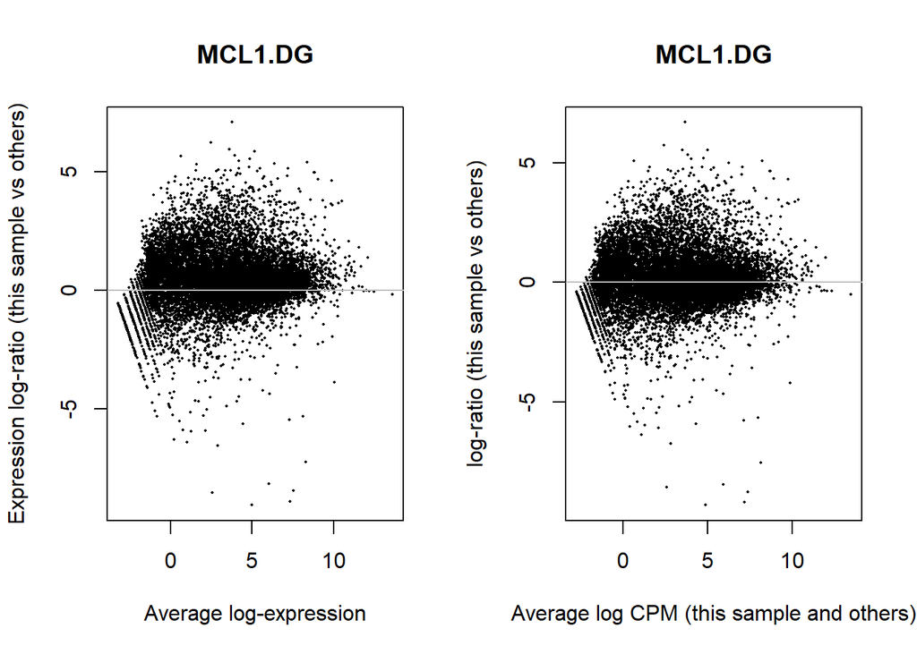

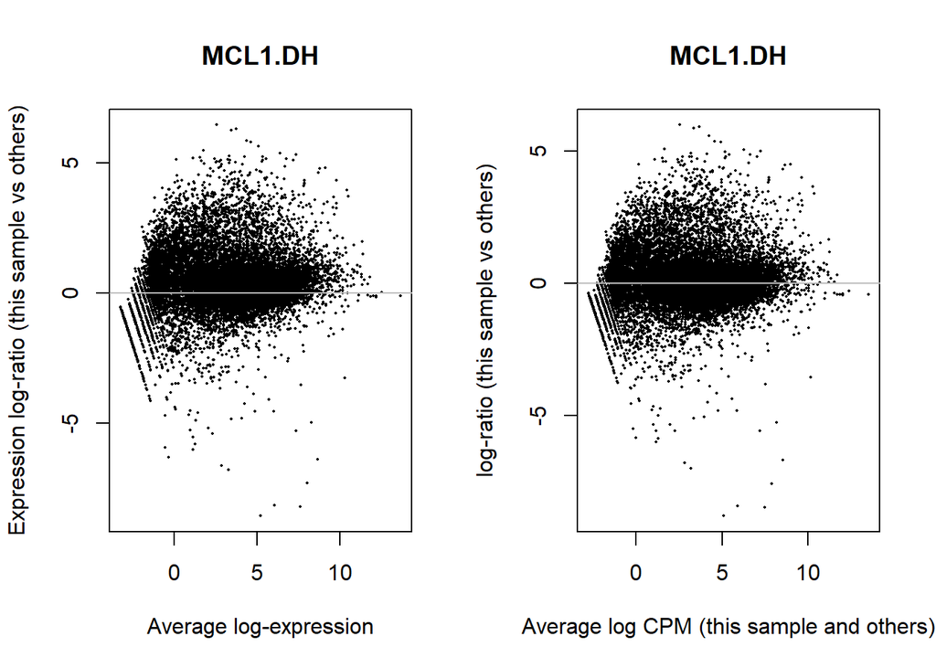

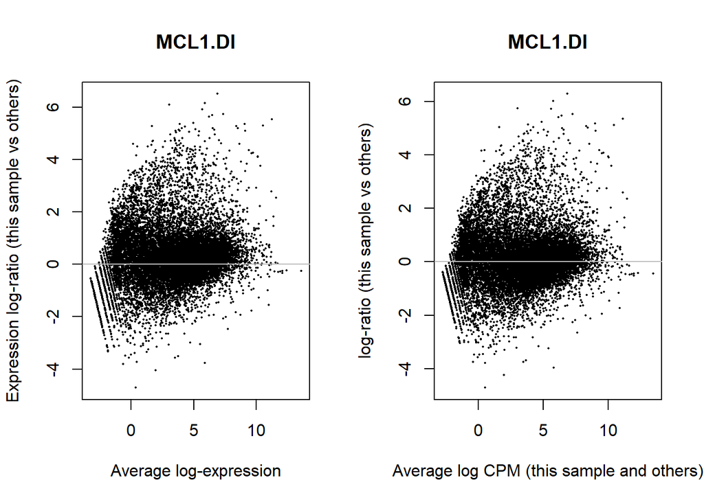

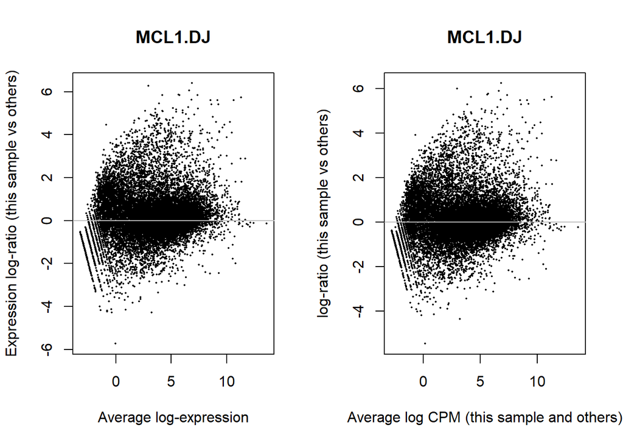

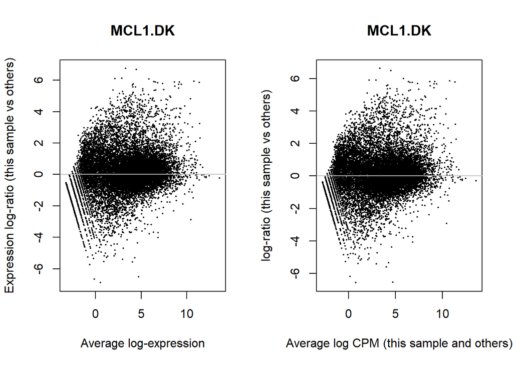

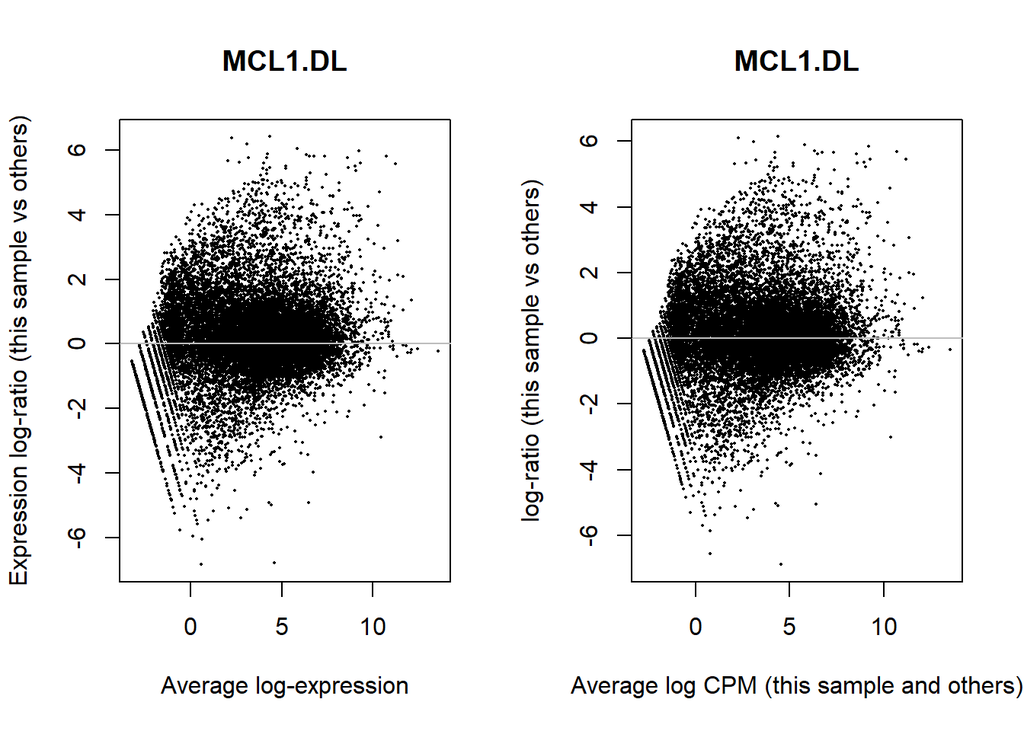

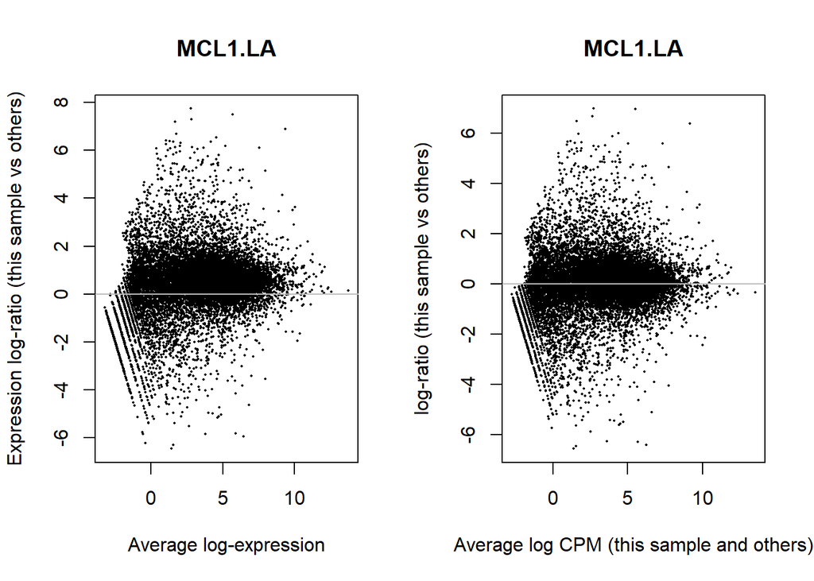

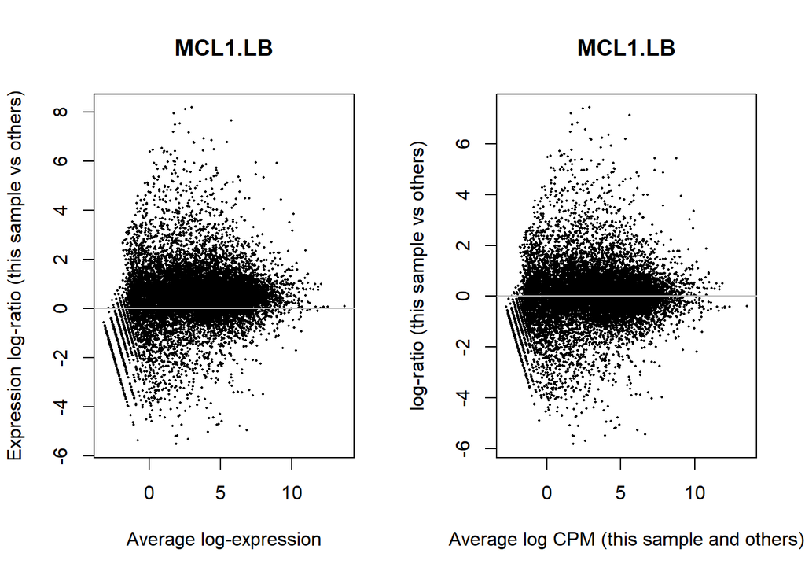

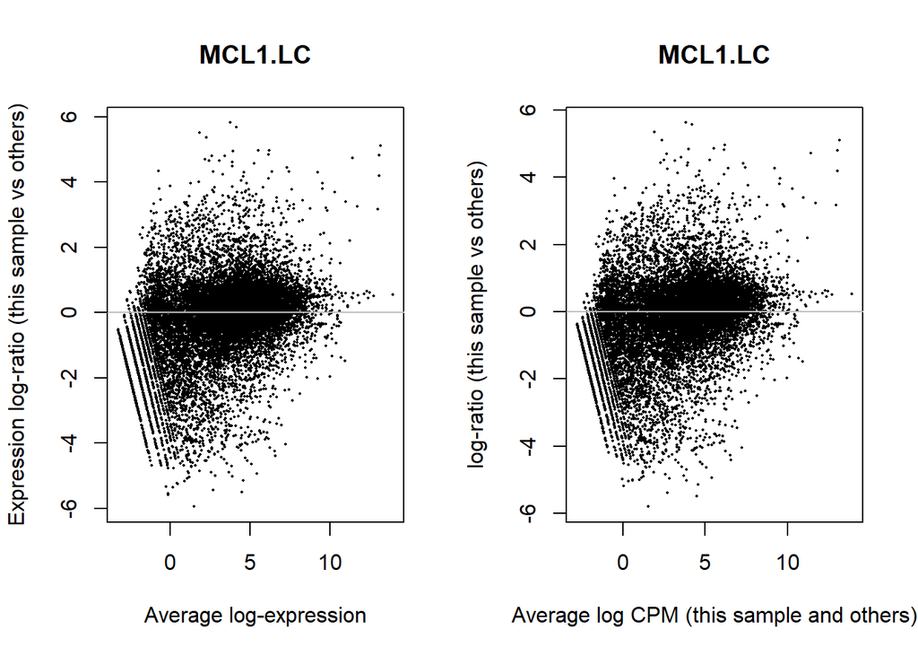

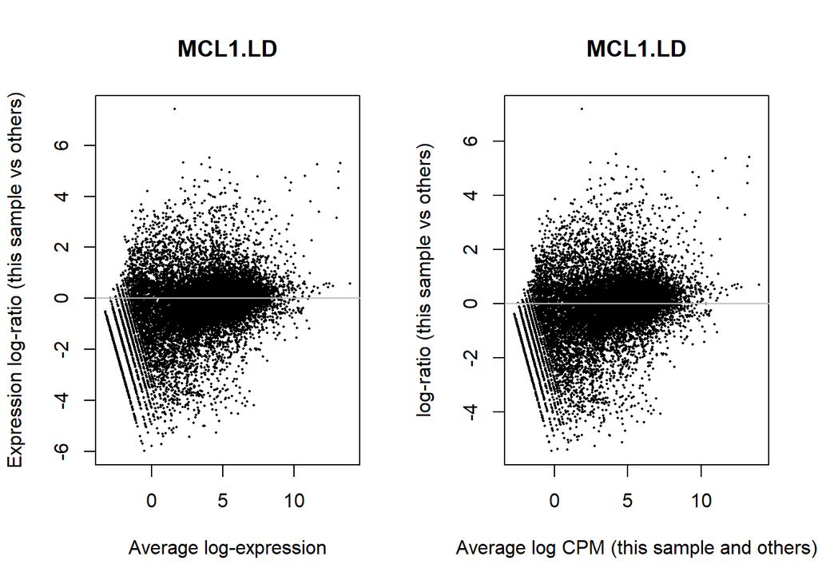

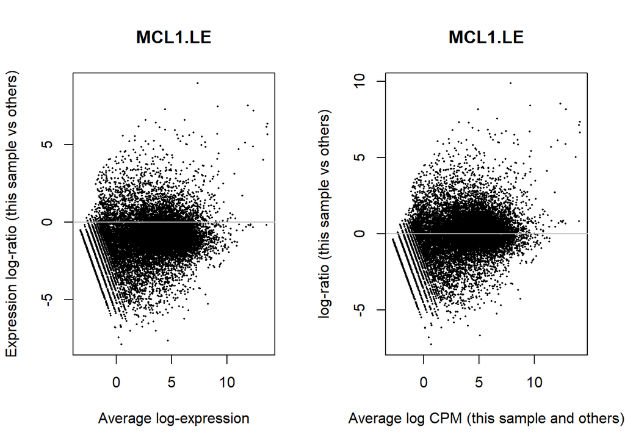

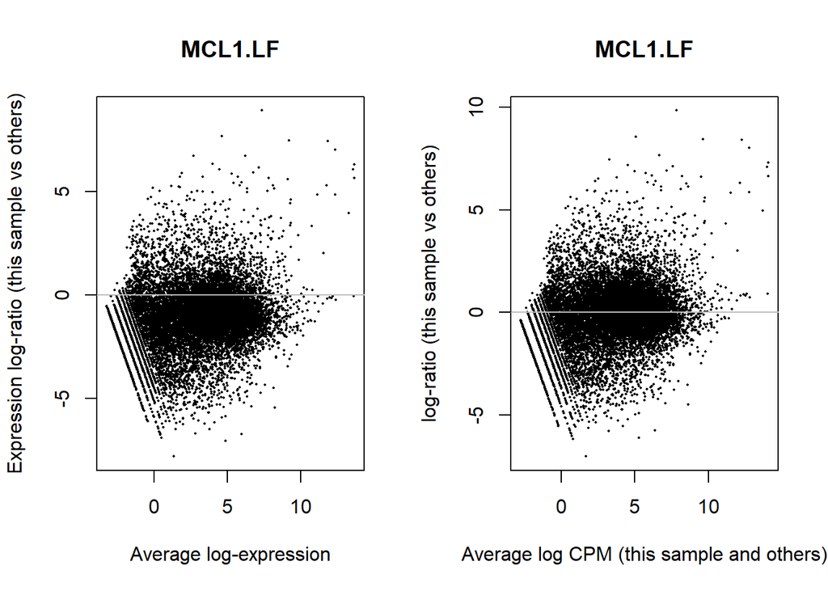

```r
par(mfrow=c(1,2))

for(x in 1:12){
  plotMD(logcounts,column = x)
  abline(h=0,col="grey")
  plotMD(dglist,column = x)
  abline(h=0,col="grey")
}
```

```r
# Specify a design matrix without an intercept term
design <- model.matrix(~ 0 + group)
colnames(design) <- levels(group)
design
```

```
   basal.lactate basal.pregnant basal.virgin luminal.lactate luminal.pregnant
1              0              0            0               0                0
2              0              0            1               0                0
3              0              1            0               0                0
4              0              1            0               0                0
5              1              0            0               0                0
6              1              0            0               0                0
7              0              0            1               0                0
8              0              0            0               0                0
9              0              0            0               0                1
10             0              0            0               0                1
11             0              0            0               1                0
12             0              0            0               1                0
   luminal.virgin
1               1
```

[output cut: 16 more lines]

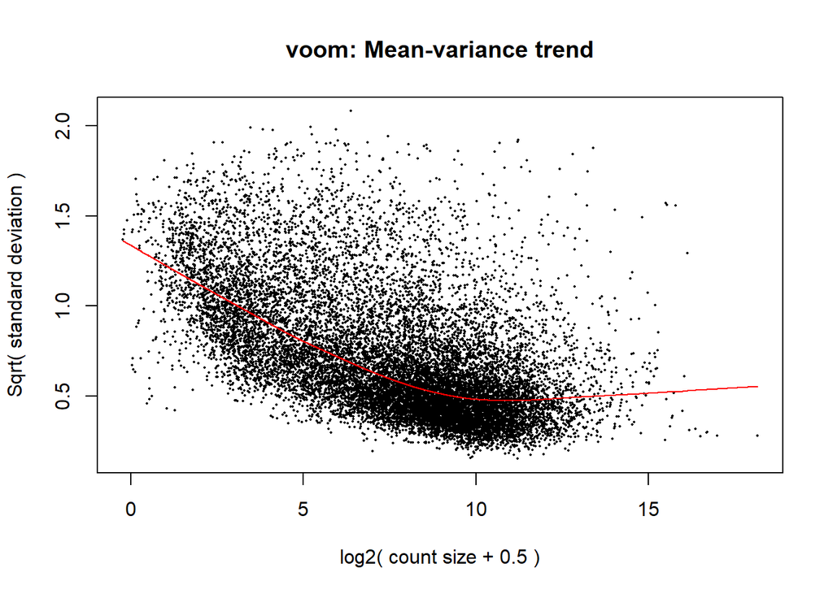

```r
# Generate a Voom (Mean-variance trend) graph and EList using the normalized factors
par(mfrow=c(1,1))
vtransform <- voom(dglist,design,plot = TRUE) # Create a plot representing this data
```

```r
vtransform # Summarize the generated EList object
```

```
An object of class "EList"
$targets
                 group lib.size norm.factors
MCL1.DG luminal.virgin 28718360     1.236899
MCL1.DH   basal.virgin 26425396     1.213949
MCL1.DI basal.pregnant 27116624     1.125564
MCL1.DJ basal.pregnant 24238743     1.069826
MCL1.DK  basal.lactate 22295130     1.035921
7 more rows ...

$E
   MCL1.DG  MCL1.DH  MCL1.DI  MCL1.DJ   MCL1.DK  MCL1.DL    MCL1.LA    MCL1.LB
1 3.932532 3.507368 1.272317 3.292541 3.9909851 3.724252 -5.8019424 -5.8887821
5 1.890808 2.787899 1.605217 2.121856 0.9642868 1.923156 -0.7575483 -0.2163568
6 3.429894 3.149591 3.637638 3.631978 3.7037376 3.636318  4.3286281  3.9707527
7 4.505933 4.285975 5.128398 5.270351 5.3801014 5.185279  4.8889286  4.8635986
9 5.804007 5.822559 5.988345 5.764344 5.7006304 5.615502  5.5801412  5.4087074
     MCL1.LC   MCL1.LD   MCL1.LE    MCL1.LF
1 -5.4816421 -5.343143 -4.709206 -4.7226146
5 -0.2721888 -1.255680 -1.901851 -0.3302972
6  4.4535229  4.016606  4.555237  4.6973455
7  4.9031416  4.993363  5.379583  5.4610208
9  5.5797290  5.512504  5.280898  5.2446116
15799 more rows ...

$weights
          [,1]      [,2]      [,3]      [,4]      [,5]      [,6]      [,7]
[1,]  1.405410  1.232373  6.340150  5.856355 11.469534 11.305692  1.276349
[2,]  3.260525  3.349678  5.159274  4.759466  3.652706  3.591488  3.474797
[3,] 12.433689 12.055729 11.751598 11.005461 10.610875 10.450204 12.418656
[4,] 16.960300 16.021159 18.400268 17.939250 17.819420 17.706243 16.359918
[5,] 19.330350 19.304465 19.510292 19.356561 18.805788 18.734374 19.385282
          [,8]      [,9]     [,10]      [,11]      [,12]
[1,]  1.434880  0.290271  0.290271  0.2902710  0.2902710
[2,]  3.329366  1.313294  1.233830  0.8120103  0.8164196
[3,] 12.648197 13.236471 12.596135 11.4659093 11.5285590
[4,] 17.134020 16.536614 15.926399 15.1785947 15.2413567
[5,] 19.376824 18.572494 18.220120 14.4330191 14.4946673
15799 more rows ...

$design
  basal.lactate basal.pregnant basal.virgin luminal.lactate luminal.pregnant
1             0              0            0               0                0
2             0              0            1               0                0
3             0              1            0               0                0
4             0              1            0               0                0
5             1              0            0               0                0
  luminal.virgin
1              1
2              0
3              0
4              0
5              0
7 more rows ...
```

```r
names(vtransform)
```

```
[1] "targets" "E"       "weights" "design"
```

```
targets

E

weights

design
```

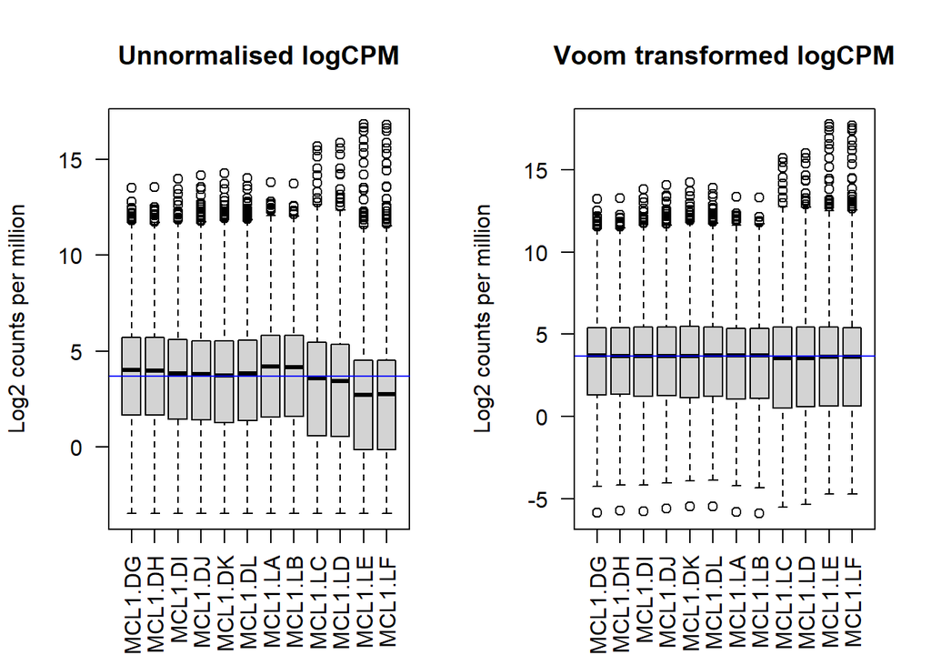

```r
par(mfrow=c(1,2))
boxplot(logcounts, xlab="", ylab="Log2 counts per million",las=2,main="Unnormalised logCPM")
## Let's add a blue horizontal line that corresponds to the median logCPM
abline(h=median(logcounts),col="blue")
boxplot(vtransform$E, xlab="", ylab="Log2 counts per million",las=2,main="Voom transformed logCPM")
## Let's add a blue horizontal line that corresponds to the median logCPM
abline(h=median(vtransform$E),col="blue")
```

```r
# Using the normalized voom transform, we can test for differential expressions using limma

# Step 1: Create a linear model to represent each gene in the data using lmFit
fitted <- lmFit(vtransform) # Estimate the means and variances of each group using a design matrix
names(fitted) # Check the names of the items. Many of these are related to statisitcal testing, but it is important to ensure that the
```

```
 [1] "coefficients"     "stdev.unscaled"   "sigma"            "df.residual"
 [5] "cov.coefficients" "pivot"            "rank"             "Amean"
 [9] "method"           "design"
```

[output not shown]

```r
# Step 2: Check for differential expression between the pregnant and lactating groups in basal cells.
contrastsMatrix <- makeContrasts(B.PregVsLac=basal.pregnant - basal.lactate,levels=design)
contrastsMatrix
```

```
                  Contrasts
Levels             B.PregVsLac
  basal.lactate             -1
  basal.pregnant             1
  basal.virgin               0
  luminal.lactate            0
  luminal.pregnant           0
  luminal.virgin             0
```

```r
# Step 3: Show statistics and estimated parameters for the two groups
fittedContrast <- contrasts.fit(fitted, contrastsMatrix) # Fit the contrast matrix based on the fitted voom transform (using linear model)
fittedContrast <- eBayes(fittedContrast) # Perform empirical Bayes on the variances & find t-values for each gene associated
dim(fittedContrast) # Verify dimension of the variances and means of each group (from the linear model above)
```

```
[1] 15804     1
```

```r
# Step 4: Use limma to generate a summary of the number of DE genes for the contrasted groups
fitSummary <- decideTests(fittedContrast)
summary(fitSummary)
```

```
       B.PregVsLac
Down            86
NotSig       15558
Up             160
```

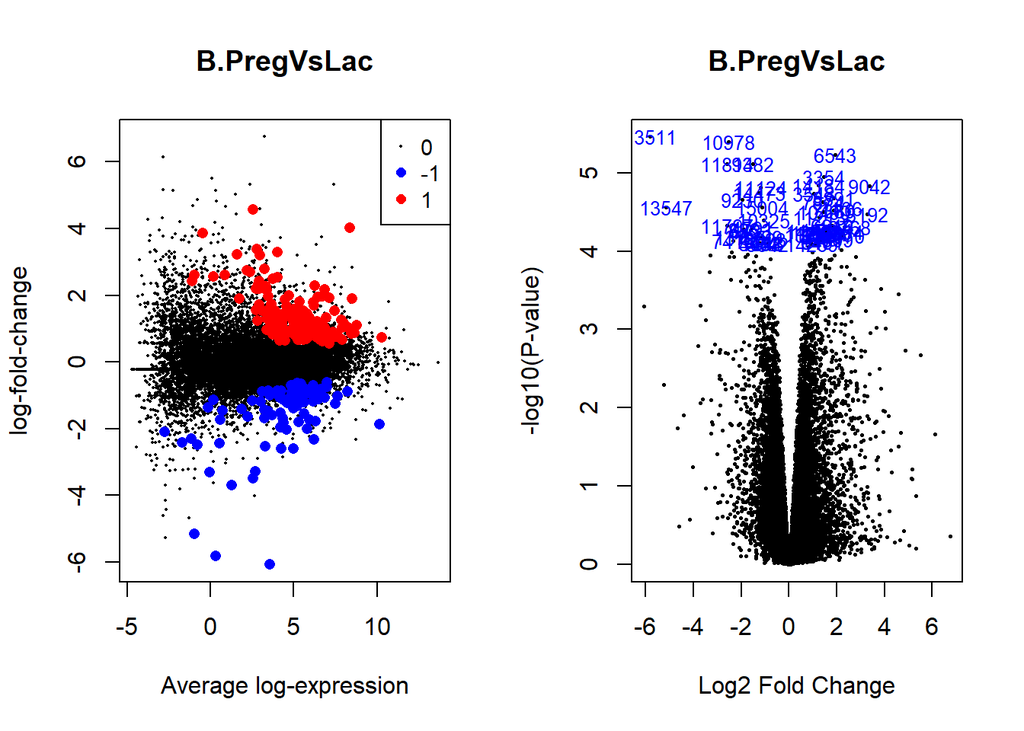

```r
# To show the differentially expressed genes, create a graph from the decideTests to highlight the statistically significant genes
par(mfrow=c(1,2))
plotMD(fittedContrast,coef=1,status=fitSummary[,"B.PregVsLac"], values = c(-1, 1), hl.col=c("blue","red"))

# To further show the results, the volcano plot allows us to highlight the top genes from the contrastTest.
volcanoplot(fittedContrast,coef=1,highlight=50,names=fittedContrast$genes$SYMBOL, main="B.PregVsLac") # Show the top 50 statistically significant DE genes
```

## Gaussian Processes

Gaussian Processes are generic supervised learning methods designed to solve regression and probabilistic classification problems. They provide the advantages of the prediction interpolating the observations, the prediction being probabilistic meaning it can compute empirical confidence intervals and refit the prediction in some regions of interest, and that the kernels can be specified. Its disadvantages include the fact that they aren’t sparse and they lose efficiency in higher dimensional spaces. Consequently, when performing regression to find the best predictor or DE genes, Gaussian processes can be utilized to find the best function model. Taking a step further, Gaussian Process Regression is a nonparametric method that calculates the probability distribution of all admissible functions that fit the data. This will be used to calculate the posterior using the training data, and then copute the predictive posterior distribution on our points of interest.

### Example of 1-D Gaussian Process using a sin function

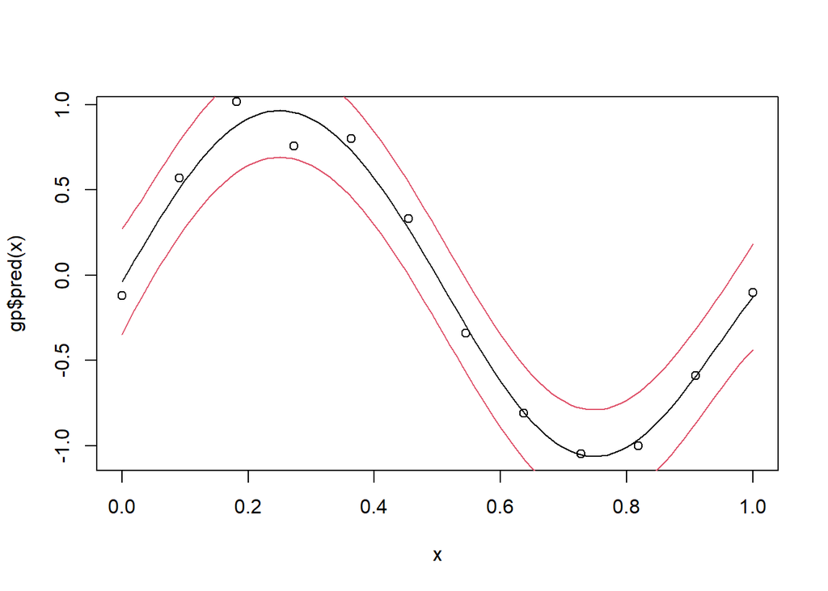

```r
library(GauPro)

#1-D, Not using kernels
n <- 12
x <- matrix(seq(0,1,length.out = n), ncol=1)
y <- sin(2*pi*x) + rnorm(n,0,1e-1)
gp <- GauPro::GauPro(X=x, Z=y)
curve(gp$pred(x));points(x,y)
curve(gp$pred(x)+2*gp$pred(x,T)$se,col=2,add=T);curve(gp$pred(x)-2*gp$pred(x,T)$se,col=2,add=T)
```

```r
#Same as above, but with no noise
n <- 12
x <- matrix(seq(0,1,length.out = n), ncol=1)
y <- (2*x) %%1
gp <- GauPro::GauPro(X=x, Z=y)
```

```
Error in deviance_fngr_joint(X, Z, K) : chol(): decomposition failed
```

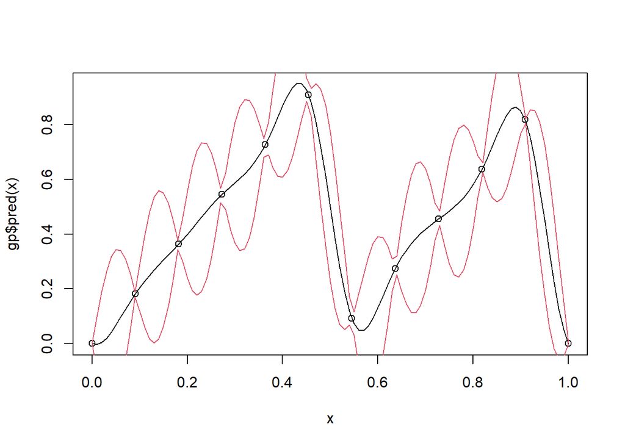

```r
curve(gp$pred(x));points(x,y)
curve(gp$pred(x)+2*gp$pred(x,T)$se,col=2,add=T);curve(gp$pred(x)-2*gp$pred(x,T)$se,col=2,add=T)
```

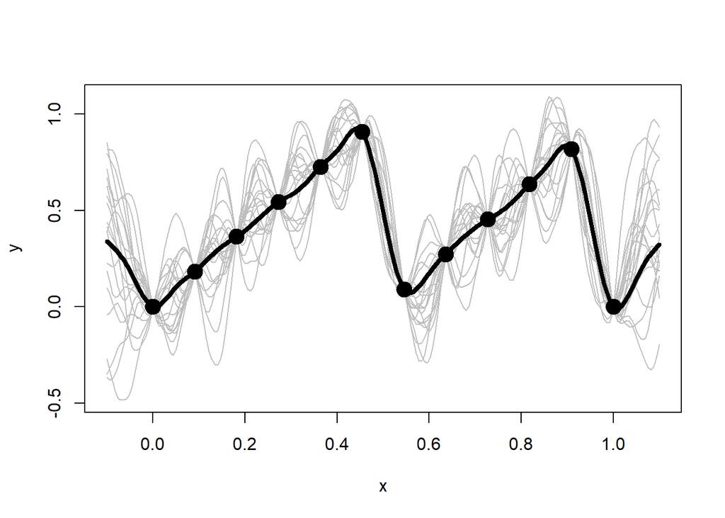

```r
#Using Kernels
kern <- Matern52$new(0)
gpk <- GauPro_kernel_model$new(matrix(x, ncol=1), y, kernel=kern, parallel=FALSE)
if (requireNamespace("MASS", quietly = TRUE)) {
  plot(gpk)
}
```

## Using the above testing Gaussian Process Code we implement it in our own data.

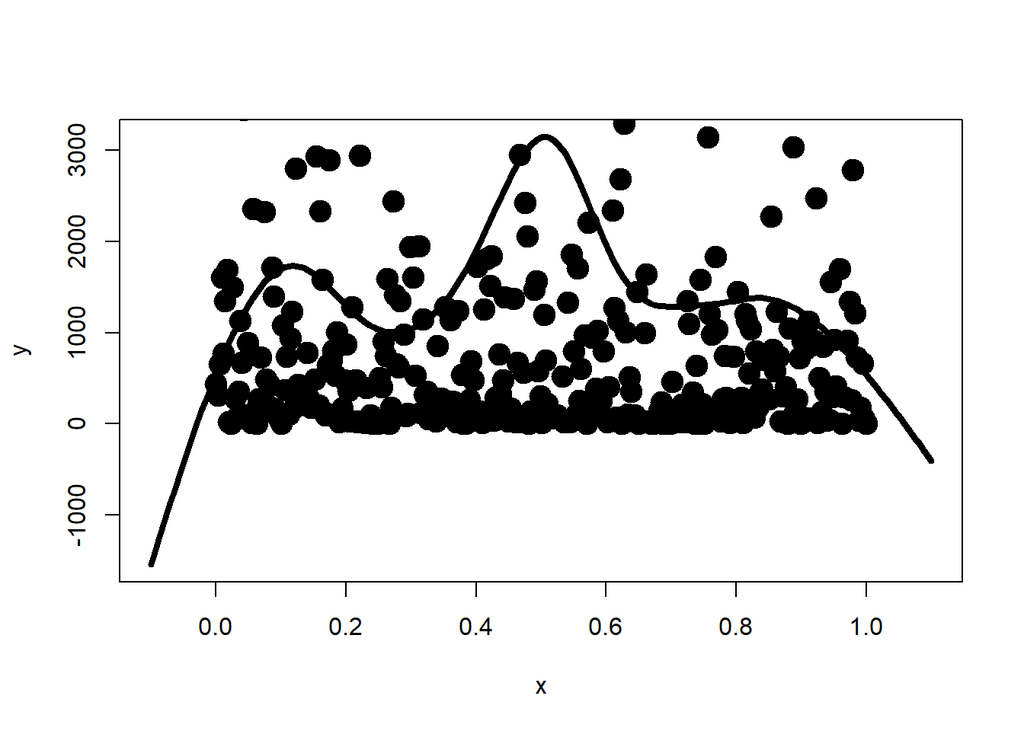

```r
library(pracma)
library(caTools)
# Reformat dglist to a suitable size
n <- 500
y <- dglist$counts[1:n,1]

sample <- sample.split(y, SplitRatio = 0.7) # Split using 70/30 ratio (backed up with research)

x_train <- matrix(seq(0,1,length.out = 350), ncol=1)
x_test <- matrix(seq(0,1,length.out = 150), ncol=1)
y_train <- subset(y, sample==TRUE)
y_test <- subset(y, sample==FALSE)

#Using Kernels
kern <- Matern52$new(0)
gpk <- GauPro_kernel_model$new(matrix(x_train, ncol=1), y_train, kernel=kern, parallel=FALSE)
if (requireNamespace("MASS", quietly = TRUE)) {
  plot(gpk)
}
```